# effMaxSG band 0.20 at 31% prevalence: constructions across the p30sgnb20 (J = 10) and p30sgnb20j20 (J = 20) cells

# 3 Harm block (one-sided = lower bound)

```r
tabH <- do.call(rbind, lapply(seq_along(bundles), function(i) {
  s <- fs_sim_bias_coverage(bundles[[i]]$results, block = "H", estimators = estimators, side = "lower")
  s$cell <- labels[i]; s
}))
tabH$estimator <- factor(tabH$estimator, levels = c("naive", "mr", "fld"),
                         labels = c("naive", "IJ two-term", "field"))
kbl(tabH[, c("cell", "estimator", "n", "b", "r", "cov1", "cov1_wilson_lo", "cov1_wilson_hi",
             "cov2", "cov2_wilson_lo", "cov2_wilson_hi", "cov1_ref", "cov2_ref")],
    digits = 3, booktabs = TRUE, row.names = FALSE,
    caption = "Harm block; cov1 = one-sided 95% LOWER-bound coverage of beta(Hhat).") |>
  kable_styling(font_size = 12)
```

Harm block; cov1 = one-sided 95% LOWER-bound coverage of beta(Hhat).

| cell | estimator | n | b | r | cov1 | cov1_wilson_lo | cov1_wilson_hi | cov2 | cov2_wilson_lo | cov2_wilson_hi | cov1_ref | cov2_ref |
| --- | --- | --- | --- | --- | --- | --- | --- | --- | --- | --- | --- | --- |
| null 1.0, prev 31%, J=10, n=1000 | naive | 1923 | 2.462 | 1.152 | 0.267 | 0.247 | 0.287 | 0.432 | 0.410 | 0.454 | 0.285 | 0.419 |
| null 1.0, prev 31%, J=10, n=1000 | IJ two-term | 1923 | 0.311 | 1.447 | 0.982 | 0.975 | 0.987 | 0.995 | 0.990 | 0.997 | 0.981 | 0.993 |
| null 1.0, prev 31%, J=10, n=1000 | field | 1923 | 0.073 | 1.191 | 0.956 | 0.946 | 0.964 | 0.963 | 0.953 | 0.970 | 0.970 | 0.980 |
| null 1.0, prev 31%, J=10, n=500 | naive | 1879 | 3.287 | 1.448 | 0.168 | 0.151 | 0.185 | 0.338 | 0.317 | 0.360 | 0.183 | 0.327 |
| null 1.0, prev 31%, J=10, n=500 | IJ two-term | 1879 | 0.476 | 1.670 | 0.984 | 0.977 | 0.988 | 0.997 | 0.993 | 0.999 | 0.988 | 0.997 |
| null 1.0, prev 31%, J=10, n=500 | field | 1879 | 0.110 | 1.350 | 0.976 | 0.968 | 0.982 | 0.988 | 0.982 | 0.992 | 0.983 | 0.991 |
| harm 1.5, prev 31%, J=10, n=1000 | naive | 2000 | 1.204 | 0.890 | 0.640 | 0.619 | 0.661 | 0.746 | 0.726 | 0.764 | 0.602 | 0.704 |
| harm 1.5, prev 31%, J=10, n=1000 | IJ two-term | 2000 | -0.178 | 1.209 | 0.982 | 0.975 | 0.987 | 0.966 | 0.957 | 0.973 | 0.985 | 0.980 |
| harm 1.5, prev 31%, J=10, n=1000 | field | 2000 | -0.209 | 1.029 | 0.959 | 0.949 | 0.966 | 0.905 | 0.891 | 0.917 | 0.971 | 0.952 |
| harm 1.5, prev 31%, J=10, n=500 | naive | 1999 | 1.907 | 1.087 | 0.472 | 0.450 | 0.494 | 0.604 | 0.583 | 0.626 | 0.452 | 0.588 |
| harm 1.5, prev 31%, J=10, n=500 | IJ two-term | 1999 | -0.015 | 1.322 | 0.985 | 0.979 | 0.990 | 0.977 | 0.970 | 0.983 | 0.986 | 0.990 |
| harm 1.5, prev 31%, J=10, n=500 | field | 1999 | -0.197 | 1.110 | 0.975 | 0.968 | 0.981 | 0.926 | 0.914 | 0.937 | 0.978 | 0.967 |
| harm 1.5, prev 31%, J=10, n=500 | naive | 1999 | 1.809 | 1.049 | 0.484 | 0.462 | 0.506 | 0.619 | 0.598 | 0.640 | 0.467 | 0.598 |
| harm 1.5, prev 31%, J=10, n=500 | IJ two-term | 1999 | -0.011 | 1.289 | 0.985 | 0.979 | 0.990 | 0.981 | 0.974 | 0.986 | 0.983 | 0.988 |
| harm 1.5, prev 31%, J=10, n=500 | field | 1999 | -0.185 | 1.081 | 0.974 | 0.967 | 0.981 | 0.925 | 0.913 | 0.936 | 0.975 | 0.963 |
| harm 1.75, prev 31%, J=10, n=500 | naive | 1999 | 1.579 | 1.019 | 0.564 | 0.542 | 0.586 | 0.678 | 0.657 | 0.698 | 0.539 | 0.662 |
| harm 1.75, prev 31%, J=10, n=500 | IJ two-term | 1999 | -0.126 | 1.254 | 0.985 | 0.979 | 0.989 | 0.967 | 0.958 | 0.974 | 0.986 | 0.985 |
| harm 1.75, prev 31%, J=10, n=500 | field | 1999 | -0.255 | 1.063 | 0.972 | 0.964 | 0.978 | 0.913 | 0.900 | 0.925 | 0.977 | 0.956 |
| harm 1.75, prev 31%, J=10, n=500 | naive | 1999 | 1.481 | 0.985 | 0.573 | 0.551 | 0.595 | 0.694 | 0.673 | 0.714 | 0.555 | 0.673 |
| harm 1.75, prev 31%, J=10, n=500 | IJ two-term | 1999 | -0.129 | 1.227 | 0.985 | 0.979 | 0.989 | 0.972 | 0.964 | 0.978 | 0.984 | 0.983 |
| harm 1.75, prev 31%, J=10, n=500 | field | 1999 | -0.251 | 1.035 | 0.970 | 0.962 | 0.977 | 0.911 | 0.898 | 0.923 | 0.975 | 0.951 |

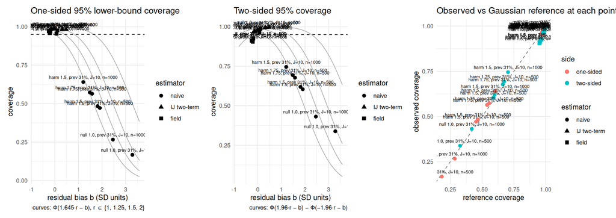

```r
fs_plot_bias_coverage(tabH, curves = curves, side = "lower")
```

# 4 The simultaneous pair

```r
wil <- function(x, n, z = qnorm(.975)) { c <- (x + z^2/(2*n))/(1+z^2/n); h <- z*sqrt(x*(1-x)/n + z^2/(4*n^2))/(1+z^2/n); c(c - h, c + h) }
tabJ <- do.call(rbind, lapply(seq_along(bundles), function(i) {
  r <- bundles[[i]]$results; d <- r[r$detected %in% 1L, ]
  d <- d[is.finite(d$betaHhat_H) & is.finite(d$betaHhat_Hc) & is.finite(d$fld_joint_gamma), ]
  pairs <- list(`separate 95%` = list(lo = d$fld_H_lo1s, up = d$fld_Hc_up1s),
                `Bonferroni`   = list(lo = d$fld_joint_bonf_loH, up = d$fld_joint_bonf_upHc),
                `calibrated`   = list(lo = d$fld_joint_loH, up = d$fld_joint_upHc))
  do.call(rbind, lapply(names(pairs), function(nm) { p <- pairs[[nm]]
    cH <- d$betaHhat_H >= p$lo; cC <- d$betaHhat_Hc <= p$up; jc <- mean(cH & cC); w <- wil(jc, nrow(d))
    data.frame(cell = labels[i], pair = nm, n = nrow(d), joint_cov = jc, wilson_lo = w[1], wilson_hi = w[2],
               cov_H = mean(cH), cov_Hc = mean(cC),
               margin_H = mean(log(d$mr_H_est) - log(p$lo)), margin_Hc = mean(log(p$up) - log(d$mr_Hc_est)),
               mean_gamma = mean(d$fld_joint_gamma), mean_corr = mean(d$fld_joint_corr), stringsAsFactors = FALSE) }))
}))
kbl(tabJ, digits = 3, booktabs = TRUE, row.names = FALSE,
    caption = "Joint coverage of (beta(Hhat) >= lower_H, beta(Hhat^c) <= upper_Hc) with Wilson intervals; margins on the log scale from the two-term de-biased estimates.") |>
  kable_styling(font_size = 12)
```

Joint coverage of (beta(Hhat) >= lower_H, beta(Hhat^c) <= upper_Hc) with Wilson intervals; margins on the log scale from the two-term de-biased estimates.

| cell | pair | n | joint_cov | wilson_lo | wilson_hi | cov_H | cov_Hc | margin_H | margin_Hc | mean_gamma | mean_corr |
| --- | --- | --- | --- | --- | --- | --- | --- | --- | --- | --- | --- |
| null 1.0, prev 31%, J=10, n=1000 | separate 95% | 1923 | 0.874 | 0.858 | 0.888 | 0.956 | 0.917 | 0.459 | 0.173 | 0.025 | 0.076 |
| null 1.0, prev 31%, J=10, n=1000 | Bonferroni | 1923 | 0.933 | 0.921 | 0.943 | 0.976 | 0.957 | 0.562 | 0.204 | 0.025 | 0.076 |
| null 1.0, prev 31%, J=10, n=1000 | calibrated | 1923 | 0.933 | 0.921 | 0.943 | 0.976 | 0.957 | 0.561 | 0.203 | 0.025 | 0.076 |
| null 1.0, prev 31%, J=10, n=500 | separate 95% | 1879 | 0.876 | 0.860 | 0.890 | 0.976 | 0.899 | 0.662 | 0.242 | 0.025 | 0.077 |
| null 1.0, prev 31%, J=10, n=500 | Bonferroni | 1879 | 0.936 | 0.924 | 0.946 | 0.991 | 0.945 | 0.804 | 0.285 | 0.025 | 0.077 |
| null 1.0, prev 31%, J=10, n=500 | calibrated | 1879 | 0.936 | 0.924 | 0.946 | 0.991 | 0.945 | 0.803 | 0.285 | 0.025 | 0.077 |
| harm 1.5, prev 31%, J=10, n=1000 | separate 95% | 2000 | 0.898 | 0.884 | 0.911 | 0.959 | 0.938 | 0.424 | 0.166 | 0.025 | 0.000 |
| harm 1.5, prev 31%, J=10, n=1000 | Bonferroni | 2000 | 0.944 | 0.933 | 0.953 | 0.979 | 0.966 | 0.524 | 0.197 | 0.025 | 0.000 |
| harm 1.5, prev 31%, J=10, n=1000 | calibrated | 2000 | 0.944 | 0.933 | 0.953 | 0.979 | 0.966 | 0.523 | 0.197 | 0.025 | 0.000 |
| harm 1.5, prev 31%, J=10, n=500 | separate 95% | 1999 | 0.879 | 0.864 | 0.893 | 0.975 | 0.902 | 0.629 | 0.235 | 0.025 | 0.041 |
| harm 1.5, prev 31%, J=10, n=500 | Bonferroni | 1999 | 0.935 | 0.924 | 0.945 | 0.989 | 0.945 | 0.766 | 0.278 | 0.025 | 0.041 |
| harm 1.5, prev 31%, J=10, n=500 | calibrated | 1999 | 0.934 | 0.923 | 0.945 | 0.989 | 0.945 | 0.766 | 0.278 | 0.025 | 0.041 |
| harm 1.5, prev 31%, J=10, n=500 | separate 95% | 1999 | 0.872 | 0.857 | 0.886 | 0.974 | 0.897 | 0.624 | 0.237 | 0.025 | 0.041 |
| harm 1.5, prev 31%, J=10, n=500 | Bonferroni | 1999 | 0.932 | 0.920 | 0.942 | 0.989 | 0.942 | 0.762 | 0.280 | 0.025 | 0.041 |
| harm 1.5, prev 31%, J=10, n=500 | calibrated | 1999 | 0.932 | 0.920 | 0.942 | 0.989 | 0.942 | 0.761 | 0.279 | 0.025 | 0.041 |
| harm 1.75, prev 31%, J=10, n=500 | separate 95% | 1999 | 0.881 | 0.867 | 0.895 | 0.972 | 0.907 | 0.615 | 0.233 | 0.025 | 0.020 |
| harm 1.75, prev 31%, J=10, n=500 | Bonferroni | 1999 | 0.934 | 0.922 | 0.944 | 0.986 | 0.947 | 0.751 | 0.276 | 0.025 | 0.020 |
| harm 1.75, prev 31%, J=10, n=500 | calibrated | 1999 | 0.934 | 0.922 | 0.944 | 0.986 | 0.947 | 0.750 | 0.275 | 0.025 | 0.020 |
| harm 1.75, prev 31%, J=10, n=500 | separate 95% | 1999 | 0.885 | 0.870 | 0.898 | 0.970 | 0.912 | 0.611 | 0.234 | 0.025 | 0.019 |
| harm 1.75, prev 31%, J=10, n=500 | Bonferroni | 1999 | 0.933 | 0.922 | 0.944 | 0.986 | 0.947 | 0.747 | 0.276 | 0.025 | 0.019 |
| harm 1.75, prev 31%, J=10, n=500 | calibrated | 1999 | 0.933 | 0.921 | 0.943 | 0.986 | 0.946 | 0.746 | 0.276 | 0.025 | 0.019 |

# 5 Re-selection regime, band and family sizes

```r
tabR <- do.call(rbind, lapply(seq_along(bundles), function(i) {
  r <- bundles[[i]]$results; d <- r[r$detected %in% 1L & is.finite(r$p_hat_H), ]
  top3 <- rowSums(cbind(d$p_hat_top1, d$p_hat_top2, d$p_hat_top3), na.rm = TRUE)
  q <- function(v) stats::quantile(v, c(.25, .5, .75), na.rm = TRUE)
  data.frame(cell = labels[i], n = nrow(d), Hhat_mean = mean(d$n_harm), Hhat_over_H = mean(d$n_harm / d$n_true),
             p_hat_H_mean = mean(d$p_hat_H), p_hat_H_q25 = q(d$p_hat_H)[1], p_hat_H_q50 = q(d$p_hat_H)[2], p_hat_H_q75 = q(d$p_hat_H)[3],
             share_argmax = mean(abs(d$p_hat_H - d$p_hat_top1) < 1e-12),
             top3_mean = mean(top3), band_mean = mean(d$band_n), band_q50 = q(d$band_n)[2], cons_qual_mean = mean(d$n_cons_qual),
             K_mean = mean(d$n_family), nfit_mean = mean(d$fld_Hc_nfit), stringsAsFactors = FALSE)
}))
kbl(tabR, digits = 3, booktabs = TRUE, row.names = FALSE,
    caption = "Per cell: p-hat(Hhat) = the gate's re-selection frequency of the selected candidate (mean, quartiles), the share of replicates where it is the family argmax, the top-3 mass, the band size on the observed effects, the consistency-qualifying count, the kept family K, and complement fits per replicate.") |>
  kable_styling(font_size = 12)
```

Per cell: p-hat(Hhat) = the gate's re-selection frequency of the selected candidate (mean, quartiles), the share of replicates where it is the family argmax, the top-3 mass, the band size on the observed effects, the consistency-qualifying count, the kept family K, and complement fits per replicate.

| cell | n | Hhat_mean | Hhat_over_H | p_hat_H_mean | p_hat_H_q25 | p_hat_H_q50 | p_hat_H_q75 | share_argmax | top3_mean | band_mean | band_q50 | cons_qual_mean | K_mean | nfit_mean |
| --- | --- | --- | --- | --- | --- | --- | --- | --- | --- | --- | --- | --- | --- | --- |
| null 1.0, prev 31%, J=10, n=1000 | 1923 | 238.060 | 0.778 | 0.070 | 0.023 | 0.046 | 0.088 | 0.223 | 0.246 | 15.266 | 11 | 91.289 | 2181.644 | 1049.986 |
| null 1.0, prev 31%, J=10, n=500 | 1879 | 115.557 | 0.758 | 0.073 | 0.022 | 0.048 | 0.096 | 0.227 | 0.294 | 9.470 | 7 | 79.275 | 2027.436 | 905.133 |
| harm 1.5, prev 31%, J=10, n=1000 | 2000 | 262.907 | 0.859 | 0.094 | 0.032 | 0.065 | 0.117 | 0.218 | 0.319 | 19.629 | 16 | 474.606 | 2181.658 | 869.604 |
| harm 1.5, prev 31%, J=10, n=500 | 1999 | 123.999 | 0.813 | 0.085 | 0.025 | 0.054 | 0.113 | 0.212 | 0.333 | 12.592 | 10 | 313.974 | 2027.439 | 825.942 |
| harm 1.5, prev 31%, J=10, n=500 | 1999 | 127.123 | 0.834 | 0.103 | 0.032 | 0.069 | 0.142 | 0.254 | 0.364 | 10.306 | 8 | 202.425 | 1228.432 | 615.019 |
| harm 1.75, prev 31%, J=10, n=500 | 1999 | 126.429 | 0.829 | 0.097 | 0.031 | 0.065 | 0.130 | 0.233 | 0.358 | 12.234 | 9 | 430.463 | 2027.439 | 777.012 |
| harm 1.75, prev 31%, J=10, n=500 | 1999 | 128.930 | 0.846 | 0.119 | 0.038 | 0.083 | 0.163 | 0.283 | 0.395 | 9.908 | 7 | 276.858 | 1228.432 | 580.252 |

# 6 Reading

Complement, one-sided upper coverage: naive 0.759/0.735/0.853/0.784/0.781/0.821/0.826 (r = 1.00/1.03/0.84/0.91/0.91/0.87/0.88); IJ two-term 0.995/0.996/0.999/0.995/0.995/0.996/0.995 (r = 1.79/1.84/1.51/1.63/1.64/1.57/1.59); field 0.917/0.899/0.938/0.902/0.897/0.907/0.912 (r = 0.94/0.96/0.78/0.85/0.85/0.81/0.82). Harm, one-sided lower coverage: naive 0.267/0.168/0.640/0.472/0.484/0.564/0.573; IJ two-term 0.982/0.984/0.982/0.985/0.985/0.985/0.985 (r = 1.45/1.67/1.21/1.32/1.29/1.25/1.23); field 0.956/0.976/0.959/0.975/0.974/0.972/0.970 (r = 1.19/1.35/1.03/1.11/1.08/1.06/1.04). Joint pair: calibrated coverage 0.933/0.936/0.944/0.934/0.932/0.934/0.933 (mean gamma 0.0250/0.0250/0.0251/0.0251/0.0251/0.0251/0.0251, mean corr +0.076/+0.077/+0.000/+0.041/+0.041/+0.020/+0.019) vs Bonferroni 0.933/0.936/0.944/0.935/0.932/0.934/0.933 vs separate 95% bounds 0.874/0.876/0.898/0.879/0.872/0.881/0.885.